# Player Categorization Assignment

Clayton Jones

2025-08-24

## 1. Introduction

For the purposes of this assignment, I evaluated the Dallas Mavericks 2023-2024 and 2024-2025 seasons in order to identify ways to improve the club for the 2025-2026 season. All analysis and visualization was done in R.

## 2. Four Factor Model

### 2.1 Model Framework

The four factor model is a framework developed by Dean Oliver that identifies four key areas (or factors) that contribute to winning basketball games: shooting, rebounding, turnovers, and free throws. According to Ryan Elmore and Andrew Urbaczewski (2024) in their book *Introduction to Sports Analytics Using R*, these four factors can be represented by effective field goal percentage (EFG), turnovers committed per possession (TPP), offensive rebounding percentage (ORR), and free throw rate (FTR). These factors typically describe a team’s offensive efficiency but can be applied to defensive efficiency as well. The formulas and values for these statistics can vary across sites, but for this analysis, I used the formulas provided by Elmore and Urbaczewski (2024) listed below:

EFG = (2 point field goals made+(1.5*3 point field goals made))/(field goals attempted))  
TPP = turnovers/possessions  
ORP = (team offensive rebounds)/(team offensive rebounds+opponent defensive rebounds)  
FTR = (free throws attempted)/(field goals attempted)

### 2.1 Data Acquisition and Preparation

To examine the four factors for the 2023-2024 seasons and 2024-2025 seasons, data from the ISAR package by Elmore (2025) that accompanies the textbook was used. To create the dataframe needed to examine the Mavericks’ rankings in 2023-2024 and 2024-2025, different datasets needed to be combined, cleaned, and transformed. The nba_games_2024 and nba_games_2025 dataframes were imported, and a column was added for 2 point field goals made. These dataframes store team statistics for each game in the respective seasons for both the home and away team (in separate rows). Because of steps taken later, the data was then ordered by game id to ensure that the home and away entries for each game were next to each other. The dataframes were then merged with the nba_adv_team_2024 and nba_adv_team_2025 dataframes, which store advanced statistics for each game. Next, unneeded columns were removed with only team name and the values needed for the four factors calculations remaining, and the data was aggregated by team to get the raw totals for each value. The four factors statistics were then calculated for both offense and defense, and a ranking for each team for each statistic was added. So, in essence, the values and rankings were computed using season total statistics as opposed to per-game averages. All that remained in the dataframes were the teams, the four factors statistics, and their rankings.

Similar steps were taken to create the dataframe needed to create a logistic regression model used to predict the outcome of a game based on the four factors. The same nba_games and nba_adv_team datasets from above were used, along with 2023 data. All data was combined into one dataframe that had every game from all three seasons. Similarly, unneeded columns were removed with only team name and the values needed for the four factors calculations remaining, and the four factors statistics for each game were calculated, as well as adding a column indicating if the team won or lost the game. **It is important to note that I calculated the four factors statistics myself and did not use the four factors dataframes provided by the ISAR package (2025), because the values in these dataframes did not represent the formulas described in the textbook.** All that remained in the dataframe were the four factors statistics and the column indicating the game outcome.

### 2.3 Team Rankings

A table showing the value of each four factors statistic as well as rankings for each statistic in the 2023-2024 and 2024-2025 seasons can be seen in Table 1 below.

Table 1: Four Factors Rankings for the Dallas Mavericks

| Factor | 2024 Value | 2024 Rank | 2025 Value | 2025 Rank |
| --- | --- | --- | --- | --- |
| Effective Field Goal Rate | 56.2% | 7 | 54.9% | 14 |
| Turnover Rate | 12.4% | 4 | 14.0% | 12 |
| Offensive Rebounding Rate | 22.2% | 24 | 23.3% | 23 |
| Free Throw Rate | 25.1% | 13 | 26.3% | 4 |
| Opponent Effective Field Goal Rate | 54.8% | 17 | 54.0% | 13 |
| Opponent Turnover Rate | 13.7% | 17 | 13.2% | 23 |
| Opponent Offensive Rebounding Rate | 24.8% | 19 | 26.9% | 25 |
| Opponent Free Throw Rate | 23.9% | 13 | 23.0% | 9 |

Overall, it appears as though the Mavericks have regressed among the four factors, specifically on offense. Last season, the Mavericks ranked in the top 10 in both effective field goal rate and turnover rate. I would imagine that some if this is due to the midseason trade of Luka Doncic, as well as the injury to Kyrie Irving late in the season. Those were the two best offensive players in the previous season, and losing Doncic for most of the season and Irving for part of the season is likely the explanation for this. The offensive rebounding rate is roughly the same, however, the team is doing a better job at drawing fouls than the previous year. On the defensive end, the team improved its ranking in effective field goal percentage and free throw rate allowed, while having worse turnover rate and rebounding rate rankings.

I think the biggest takeaway from this is that the team is very deficient in regard to rebounding. The Mavericks are in the bottom third for both offensive and defensive rebound rate. Dallas is also in the bottom third for opponent turnover rate, meaning that their defense is not generating enough turnovers. The team excels at getting to the free throw line and not letting the opponent get to the free throw line and is middle of the pack in effective field goal rate, turnover rate, and opponent effective field goal rate.

### 2.4 Expected Wins and Losses

In *Introduction to Sports Analytics Using R*, Elmore and Urbaczewski (2024) create a logistic regression model to predict wins and losses based on the offensive four factors. I wanted to do the same to be able to determine the number of expected wins for the 2024-2025 season, but I wanted to test if including both offensive and defensive numbers would improve the model. To avoid collinearity when building the model that included both offensive and defensive statistics, only one row was kept for each game, as the second row is all of the same numbers just shifted around for the team the row is identifying and the opponent. The data was split into training and testing data using an 80/20 split, and the glm() function was used to create the “offensive” model (with only offensive statistics) and the “cumulative” model (with both offensive and defensive statistics). The “family = binomial” declaration was included in the glm() function because these were to be logistic regression models with a binary target variable. The summary output for the cumulative model built on the training set can be seen below, and the output for the offensive model can be seen in Appendix A.

```
##
## Call:
## glm(formula = win ~ ., family = "binomial", data = train)
##
## Coefficients:
##              Estimate Std. Error z value Pr(>|z|)
## (Intercept)    -0.160      1.242  -0.129    0.897
## efg_pct        80.687      4.083  19.764   <2e-16 ***
## oreb_pct       30.371      1.835  16.553   <2e-16 ***
## tov_pct       -66.358      3.991 -16.626   <2e-16 ***
## fta_rate       13.851      1.235  11.214   <2e-16 ***
## opp_efg_pct   -80.030      3.976 -20.129   <2e-16 ***
## opp_oreb_pct  -29.874      1.823 -16.384   <2e-16 ***
## opp_tov_pct    62.173      3.812  16.311   <2e-16 ***
## opp_fta_rate  -13.052      1.177 -11.091   <2e-16 ***
## ---
## Signif. codes:  0 '***' 0.001 '**' 0.01 '*' 0.05 '.' 0.1 ' ' 1
##
## (Dispersion parameter for binomial family taken to be 1)
##
##     Null deviance: 4092.23  on 2951  degrees of freedom
## Residual deviance:  840.79  on 2943  degrees of freedom
## AIC: 858.79
##
## Number of Fisher Scoring iterations: 8
```

The trained model was then used to predict the outcome for each Mavericks game in the 2024-2025 season based on the offensive and defensive four factors. The model was extremely accurate, predicting a record of 40-42 when the team’s actual record was 39-43.

Table 2: Predicted Wins/Losses Based on Four Factor Model vs. Actual

|  | Wins | Losses |
| --- | --- | --- |
| Predicted | 40 | 42 |
| Actual | 39 | 43 |

## 3. Player Categorization

### 3.1 Model Framework

The next step in the analysis was to determine a new classification framework for identifying player types, which could then be used to analyze current roster construction and future roster decisions. Many similar analyses have been done, but I found the analysis done by Han Man (2017) to be the most useful and applicable. Much of my analysis is similar to the analysis done by Man (2017).

### 3.2 Data Acquisition and Cleaning

The first step was to acquire data by which to build the new framework. Similar to an analysis done by Alex Cheng (2017), I wanted to use both per 100 possession statistics and advanced statistics because these statistics are standardized and not influenced by playing time. Similar to the analysis done by Man (2017), I wanted to treat each season for each player as their own individual player, because players can evolve from year to year. First, per 100 possession data was downloaded from Basketball Reference for the 2020-2021 season (“2020-21 NBA Player Stats: Per 100 Possessions,” n.d.), the 2021-2022 season (“2021-22 NBA Player Stats: Per 100 Possessions,” n.d.), the 2022-2023 season (“2022-23 NBA Player Stats: Per 100 Possessions,” n.d.), the 2023-2024 season (“2023-24 NBA Player Stats: Per 100 Possessions,” n.d.), and the 2024-2025 season (“2024-25 NBA Player Stats: Per 100 Possessions,” n.d.). Similarly, advanced statistics data was downloaded from Basketball Reference for the 2020-2021 season (“2020-21 NBA Player Stats: Advanced,” n.d.), the 2021-2022 season (“2021-22 NBA Player Stats: Advanced,” n.d.), the 2022-2023 season (“2022-23 NBA Player Stats: Advanced,” n.d.), the 2023-2024 season (“2023-24 NBA Player Stats: Advanced,” n.d.), and the 2024-2025 season (“2024-25 NBA Player Stats: Advanced,” n.d.).

Once the data was acquired, it was loaded into R with the read.csv() function. The per 100 possessions data and advanced data and were combined for each year. I also added the season to the player’s name to be able to distinguish between seasons (i.e. “LeBron James (24-25). Then, all five years were combined to make one dataset, “_per100poss” was added to per 100 possession variable names, and players with less than 500 minutes played were filtered out to avoid having players with small sample sizes and unsustainable rates affect the results. The dataframe was checked for null data, which only showed up in the 3P% column for players who did not attempt any three pointers, so those null values were replaced with zeroes. The data was then ready to be used and had a total of 1,838 observations.

### 3.2 Principal Component Analysis

To reduce the dimensionality of the data, I used principal component analysis to find the top features that encompassed all 33 measures of player performance. This was done by scaling the data and using prcomp() formula. A summary of the principal component analysis can be seen below.

```
## Importance of components:
##                           PC1    PC2    PC3     PC4     PC5     PC6     PC7
## Standard deviation     3.3829 2.7878 1.9302 1.41144 1.25884 1.02259 0.99896
## Proportion of Variance 0.3468 0.2355 0.1129 0.06037 0.04802 0.03169 0.03024
## Cumulative Proportion  0.3468 0.5823 0.6952 0.75557 0.80359 0.83528 0.86552
##                            PC8     PC9    PC10    PC11    PC12    PC13    PC14
## Standard deviation     0.91436 0.79795 0.73353 0.72827 0.65522 0.63531 0.53400
## Proportion of Variance 0.02534 0.01929 0.01631 0.01607 0.01301 0.01223 0.00864
## Cumulative Proportion  0.89085 0.91015 0.92645 0.94253 0.95554 0.96777 0.97641
##                           PC15    PC16   PC17   PC18    PC19    PC20    PC21
## Standard deviation     0.51212 0.40257 0.3808 0.2693 0.21721 0.18417 0.14552
## Proportion of Variance 0.00795 0.00491 0.0044 0.0022 0.00143 0.00103 0.00064
## Cumulative Proportion  0.98436 0.98927 0.9937 0.9959 0.99729 0.99832 0.99896
##                           PC22    PC23    PC24    PC25    PC26    PC27    PC28
## Standard deviation     0.10750 0.09250 0.07969 0.05603 0.04636 0.03760 0.01886
## Proportion of Variance 0.00035 0.00026 0.00019 0.00010 0.00007 0.00004 0.00001
## Cumulative Proportion  0.99931 0.99957 0.99976 0.99986 0.99992 0.99996 0.99998
##                           PC29    PC30    PC31     PC32     PC33
## Standard deviation     0.01814 0.01482 0.01257 0.008698 0.006252
## Proportion of Variance 0.00001 0.00001 0.00000 0.000000 0.000000
## Cumulative Proportion  0.99999 0.99999 1.00000 1.000000 1.000000
```

The output seems like a lot of numbers, but the important things to note are the proportion of variance and cumulative variance for each principal component. The proportion of variance is the amount of variance in the data that can be attributed to that specific principal component, and the cumulative proportion shows how much variance in the data is explained by the principal components up to that point. It is common practice to set a 95% threshold for selecting principal components, so principal components 1-12 were selected to classify players. These are the measures by which players were grouped together.

In this case of classifying basketball players, principal components can also be thought of as player traits. Within each principal component, or trait, there are loadings, which indicate the weight or importance of each original variable on the principal component. To properly see the makeup of each trait, or to see which original variables were most important to the principal component, I examined the top 5 loadings for each principal component in terms of absolute value, and named the traits based on the makeup. For example, the first principal component is most influenced by player efficiency rating, win shares, and shooting. The loadings are negative, which means that low values in these measures create a high value for the principal component. For this specific principal component, a higher value indicates worse production, so I named the trait “Low Efficiency/Production.” This is very similar to what was done by Man (2017), and some of the names of the traits come from his work. A plot showing each trait and the top 5 loadings can be seen below. The plots go in order, so the top left plot shows the first principal component, the top middle shows the second, and so on.

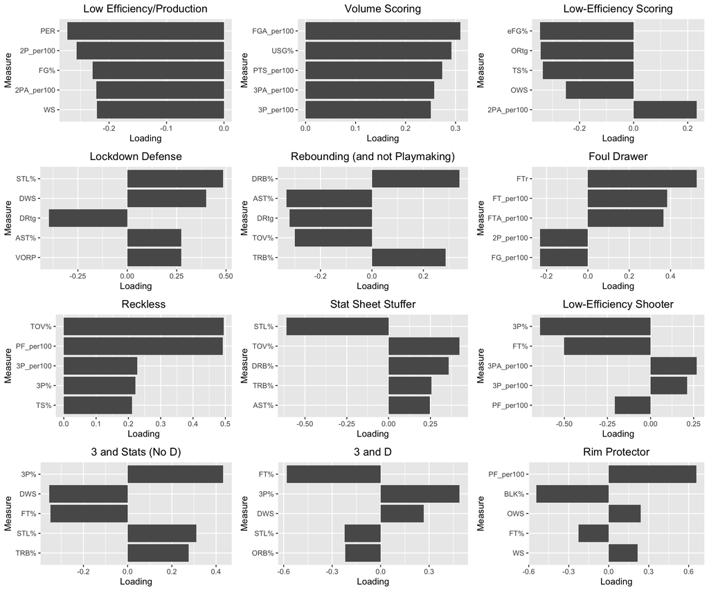

### 3.3 New Classification Framework and Player Archetypes using Clustering

Now that the traits (or principal components) had been selected, the players could be clustered in order to determine the new classification framework and player archetypes. I tested both k-means clustering and hierarchal clustering to see which method best clustered the players. K-means clustering was more effective, as hierarchal clustering was unable to create meaningful clusters. This is the opposite result of the analysis done by Man (2017).  
Now that k-means had been selected as the chose method of clustering, I needed to determine the correct number of clusters. This can be done using silhouette score. A plot showing the silhouette score for each number of clusters 1-10 can be seen in the figure below. The plot suggests that the optimal number of clusters is 2, but that is too few for trying to define a new classification framework for NBA players. It can be seen that the silhouette score decreases from 4 to 8 but sees a slight uptick from 8 to 9. Because of this, I used 9 clusters to create 9 different player archetypes.

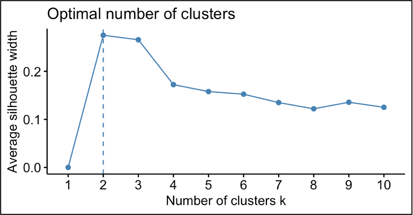

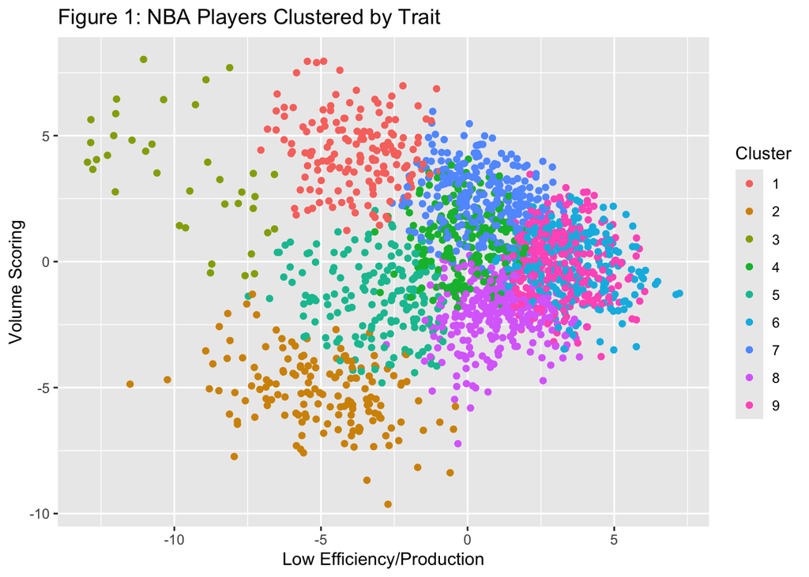

After creating the clusters, I could then look at the median characteristics of each cluster in order to create the archetypes. A heatmap can be seen in Figure 2 below that shows the median value for each trait (principal component) for each cluster.

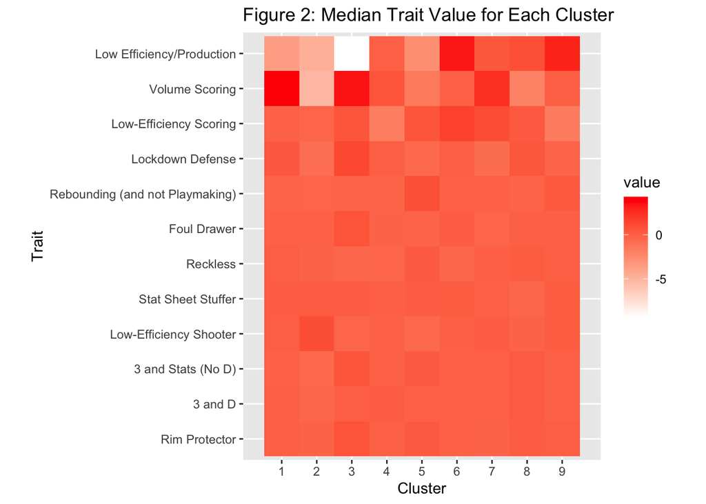

Now that I knew what characteristics made up each cluster, I was able to name the player archetypes. The nine player archetypes that I came up with were Defensive-Minded Wing, Elite Offensive Force, Efficient Scoring and Rebounding Big, Two-Way Guard, Role-Playing Wing, Scoring Guard, Rim-Running Big, Bench Wing, and Elite Big. I tried to define each cluster with a position (guard, wing, big) but was unsuccessful. The Elite Offensive Forces were made up of all positions, which is why that does not have a position attached to it. The archetypes, besides guards, are also intended to identify role levels. Elite Offensive Forces and Elite Bigs are elite players should be the stars of the team. Efficient Scoring and Rebounding Bigs and Two-Way Guards should be starters as well but can sometimes come off the bench. Scoring Guards and Rim-Running Bigs can start or come off the bench as well but are typically better suited for a sixth-man type role. Role-Playing Wings and Defensive-Minded Wings should be considered role players and can realistically start or come off the bench. Finally, Bench Wings should be end of the rotation players.

After creating the archetypes, I created a plot similar to Figure 1 for each archetype, plotting their values on the first two traits and labeling the points. A plot for the Elite Big category can be seen in Figure 3 below, and the rest of the plots can be seen in Figures 4-11 of Appendix B.

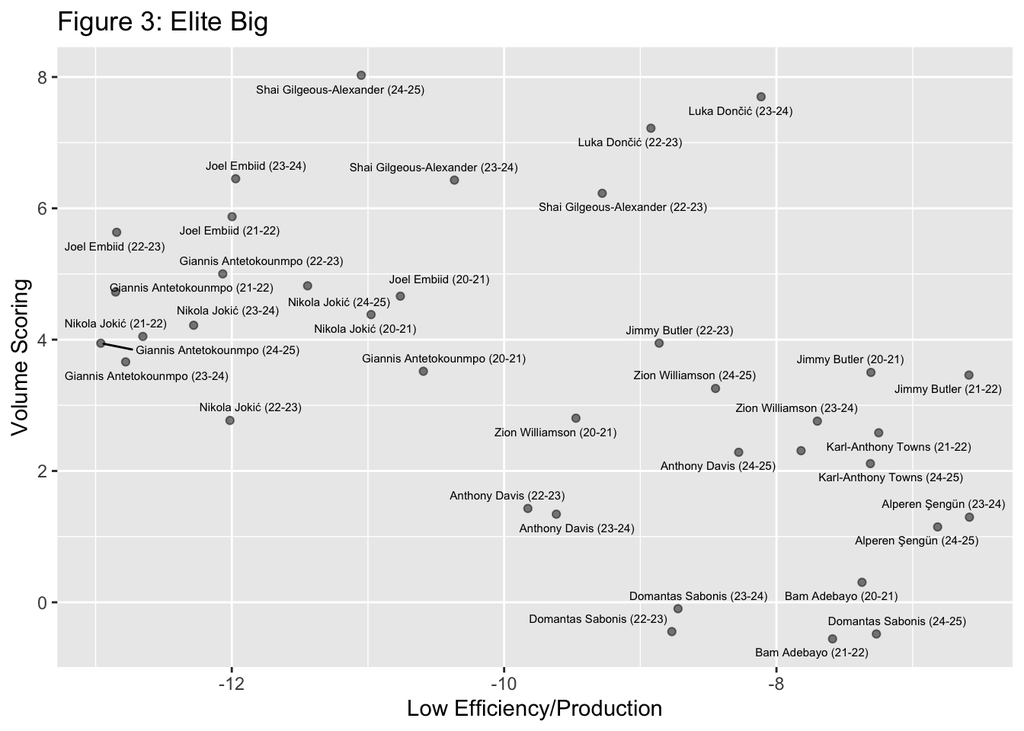

Of course, there are some players in this category that make you scratch your head a little bit. Both Luka Doncic and Shai Gilgeous-Alexander are considered guards, and it is interesting that they showed up in this archetype. However, because of the other data points captured in this plot, I was very encouraged that they all ended up in the same archetype, because these truly have been the elite big men in the NBA over the last five years.

### 3.4 Current Roster Analysis and Recommendations

Given the newly defined player classification framework and archetypes, we can analyze the Mavericks’ current roster in order to help make future roster decisions. A table showing the current roster at the end of the 2024-2025 season can be seen in Table 3 below, as well as the archetype for each player. I tried to show the top 5 players as the starters and the bench players after that. Only players with more than 500 minutes played are shown.

Table 3: Current Mavericks Roster

| Player | Archetype |
| --- | --- |
| Kyrie Irving | Elite Offensive Force |
| Klay Thompson | Role-Playing Wing |
| P.J. Washington | Defensive-Minded Wing |
| Anthony Davis | Elite Big |
| Daniel Gafford | Rim-Running Big |
| Spencer Dinwiddie | Scoring Guard |
| Dereck Lively II | Rim-Running Big |
| Naji Marshall | Two-Way Guard |
| Caleb Martin | Bench Wing |
| Max Christie | Role-Playing Wing |
| Jaden Hardy | Scoring Guard |
| Dwight Powell | Rim-Running Big |
| Olivier-Maxence Prosper | Bench Wing |
| Kessler Edwards | Defensive-Minded Wing |

In regard to the current roster, I believe that the roster is in better shape than the four factor rankings and record from 2024-2025 indicate. The team was plagued by injuries all year long, so hopefully getting some better injury luck in 2025-2026 can help the team bounce back. However, Kyrie Irving is set to miss a lot of the 2025-2026 season due to the ACL injury he suffered in the 2024-2025 season. Given the lack of other starting caliber guards on the roster, I think that finding one is the biggest need heading into next season. Because of Irving’s offensive prowess, I would look to add a Two-Way Guard if it is not possible to add an Elite Offensive Force.

Another way to look at what the team needs is by looking at the results from the four factor analysis. In the regression model, EFG contributed the most to winning, followed by TPP, ORR, and TPP. The Mavericks were middle of the pack in terms of EFG and Opponent EFG, so improving both of these metrics should be the top priority. This could mean targeting Two Way Guards like mentioned above, who are effective on both offense and defense. As mentioned previously, the team was also in the bottom third for both ORR and Opponent ORR. This is an area that the team should look to improve. Realistically, this can best be done by targeting Efficient Scoring and Rebounding Bigs. This player archetype places an emphasis on rebounding and scoring, making it the perfect type of player for the Mavs to look to acquire.

In summary, by analyzing the current roster and the four factors statistics, my recommendation is to try to acquire a Two-Way Guard and an Efficient and Scoring and Rebounding Big. EFG has the highest impact on winning, and the acquisition of a Two-Way Guard would hopefully help boost this metric. The team is deficient in rebounding, so the team should look to add a Scoring and Rebounding Big to help address that deficiency. Of course, the most impactful acquisition would be an Elite Offensive Force (especially with Irving out for a good portion of the season), but given the salary cap and luxury tax restrictions, I do not see this as a realistic possibility. Overall, by making smart acquisitions, as well as hopefully a little better injury luck, this team could be back in the playoffs next season.

### References

“2020-21 NBA Player Stats: Advanced.” n.d. Basketball Reference.  
https://www.basketball-reference.com/leagues/NBA_2021_advanced.html.  
“2020-21 NBA Player Stats: Per 100 Possessions.” n.d. Basketball Reference.  
https://www.basketball-reference.com/leagues/NBA_2021_per_poss.html.  
“2021-22 NBA Player Stats: Advanced.” n.d. Basketball Reference.  
https://www.basketball-reference.com/leagues/NBA_2022_advanced.html.  
“2021-22 NBA Player Stats: Per 100 Possessions.” n.d. Basketball Reference.  
https://www.basketball-reference.com/leagues/NBA_2022_per_poss.html.  
“2022-23 NBA Player Stats: Advanced.” n.d. Basketball Reference.  
https://www.basketball-reference.com/leagues/NBA_2023_advanced.html.  
“2022-23 NBA Player Stats: Per 100 Possessions.” n.d. Basketball Reference.  
https://www.basketball-reference.com/leagues/NBA_2023_per_poss.html.  
“2023-24 NBA Player Stats: Advanced.” n.d. Basketball Reference.  
https://www.basketball-reference.com/leagues/NBA_2024_advanced.html.  
“2023-24 NBA Player Stats: Per 100 Possessions.” n.d. Basketball Reference.  
https://www.basketball-reference.com/leagues/NBA_2024_per_poss.html.  
“2024-25 NBA Player Stats: Advanced.” n.d. Basketball Reference.  
https://www.basketball-reference.com/leagues/NBA_2025_advanced.html.  
“2024-25 NBA Player Stats: Per 100 Possessions.” n.d. Basketball Reference.  
https://www.basketball-reference.com/leagues/NBA_2025_per_poss.html.  
Cheng, Alex. 2017. “Using Machine Learning to Find the 8 Types of Players in the NBA.” Medium.  
https://medium.com/fastbreak-data/classifying-the-modern-nba-player-with-machine-learning-539da03bb824.  
Elmore, Ryan, and Andrew Urbaczewski. 2024. Introduction to Sports Analytics Using R. Prospect Press.  
Elmore, Ryan. 2025. *ISAR: Introduction to Sports Analytics using R (ISAR) Data*. doi:10.32614/CRAN.package.ISAR  
Man, Han. 2017. “Defining Modern NBA Player Positions - Applying Machine Learning to Uncover Functional Roles in Basketball.” Medium.  
https://medium.com/hanman/the-evolution-of-nba-player-positions-using-unsupervised-clustering-to-uncover-functional-roles-a1d07089935c.

### Appendix A

```
##
## Call:
## glm(formula = win ~ efg_pct + oreb_pct + tov_pct + fta_rate,
##     family = "binomial", data = train)
##
## Coefficients:
##             Estimate Std. Error z value Pr(>|z|)
## (Intercept) -12.8520     0.5701 -22.545   <2e-16 ***
## efg_pct      21.2223     0.8966  23.671   <2e-16 ***
## oreb_pct      7.2882     0.6279  11.607   <2e-16 ***
## tov_pct     -11.9428     1.2097  -9.872   <2e-16 ***
## fta_rate      4.4909     0.5291   8.487   <2e-16 ***
## ---
## Signif. codes:  0 '***' 0.001 '**' 0.01 '*' 0.05 '.' 0.1 ' ' 1
##
## (Dispersion parameter for binomial family taken to be 1)
##
##     Null deviance: 4092.2  on 2951  degrees of freedom
## Residual deviance: 3100.1  on 2947  degrees of freedom
## AIC: 3110.1
##
## Number of Fisher Scoring iterations: 4
```

### Appendix B

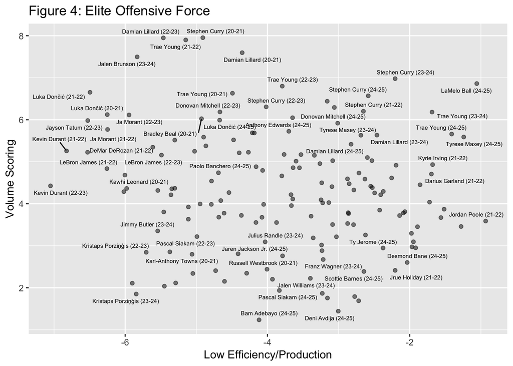

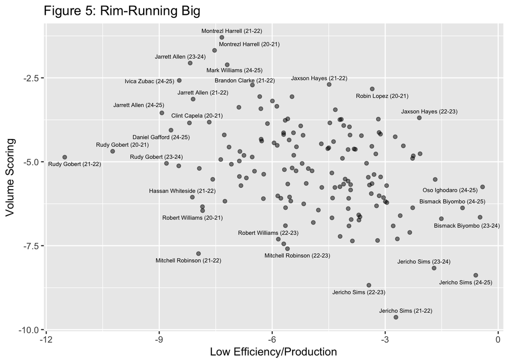

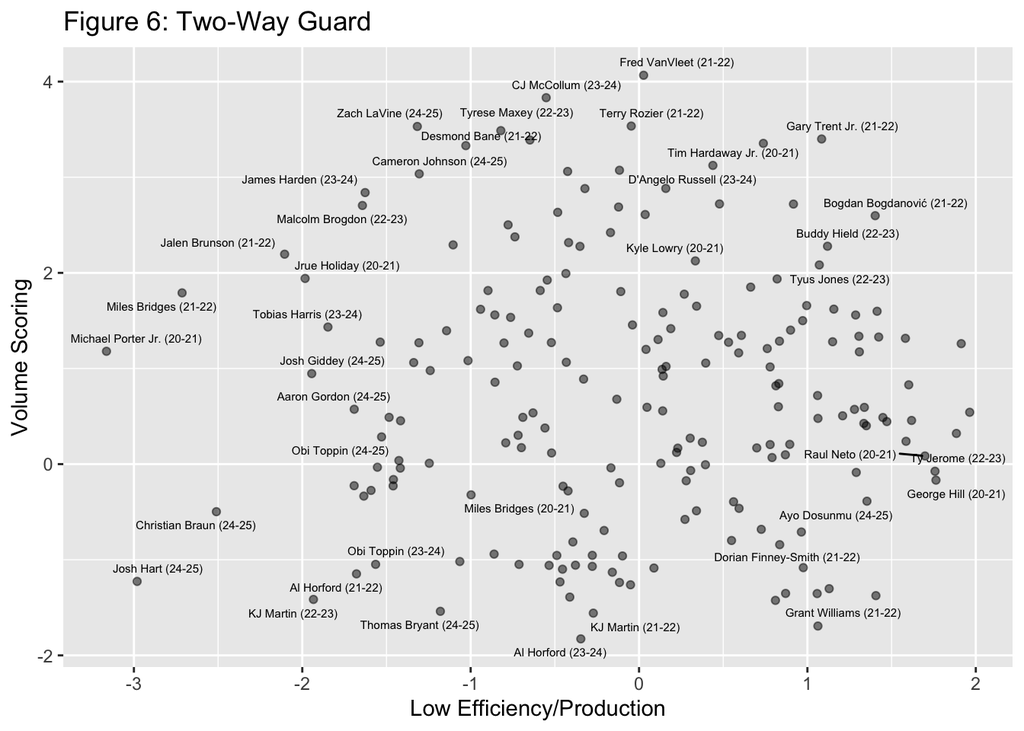

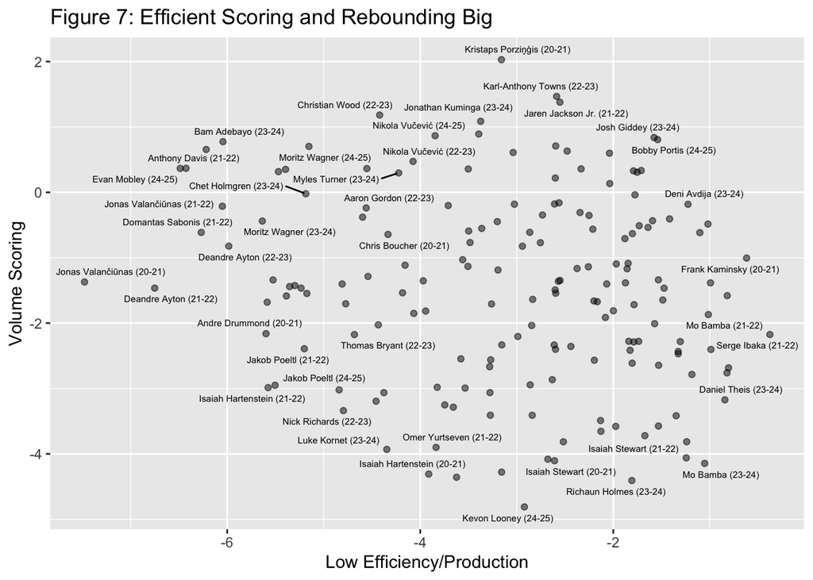

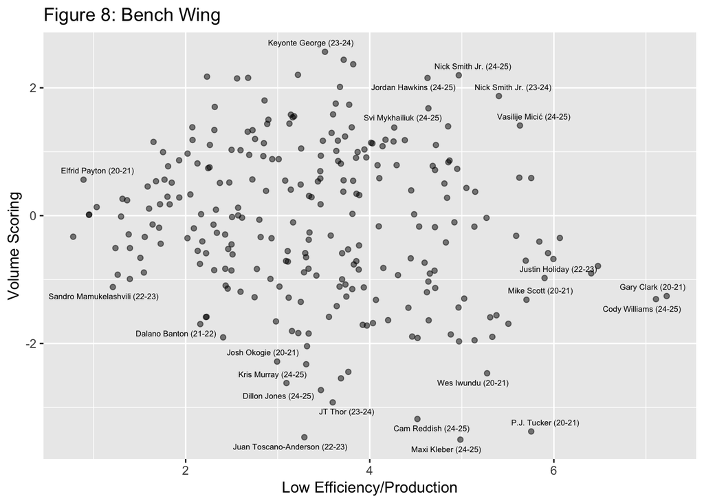

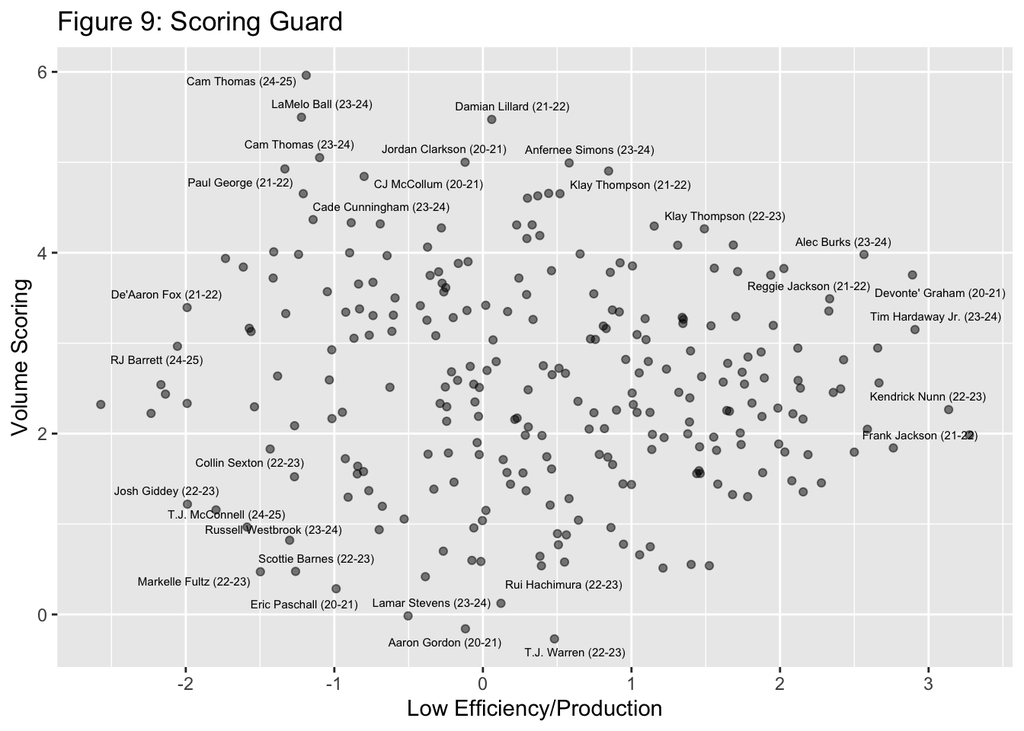

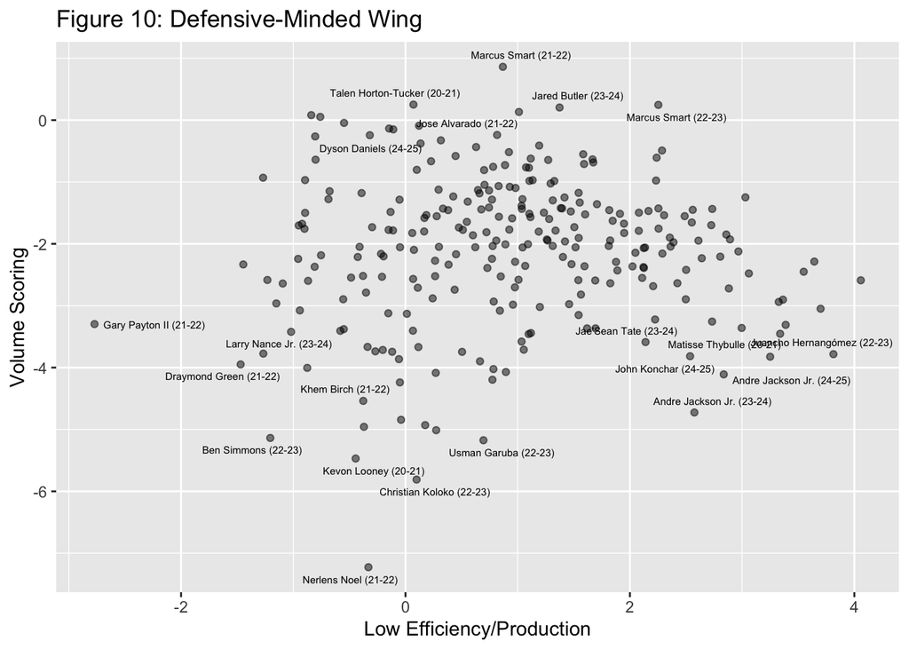

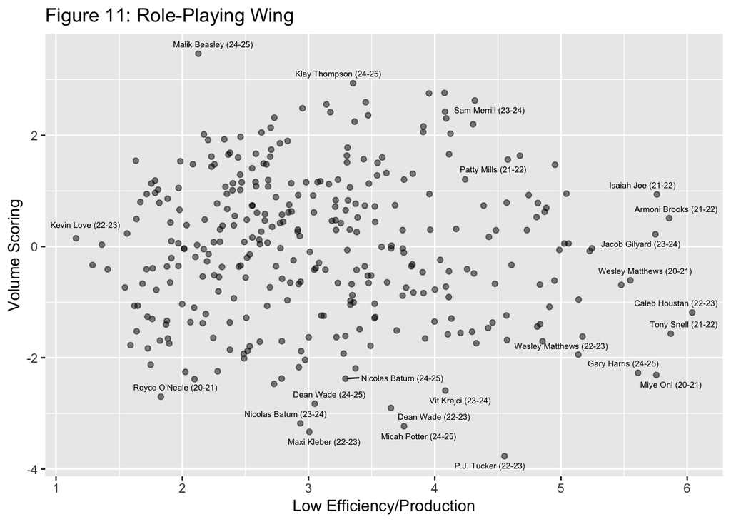